# EMIAppHelp

Pavitter Singh

Friday, February 20, 2015

Many of us take loan to buy our house and pay monthly installments. This App is to calculate how much monthly installment one has to pay for a given amount of loan at a fixed annual rate of interest, and for a given term in Years.

## Inputs that it takes are:

- Loan Amount in $
- Annual Rate of Interest in Percentage
- Loan Term in Years

## How it Looks

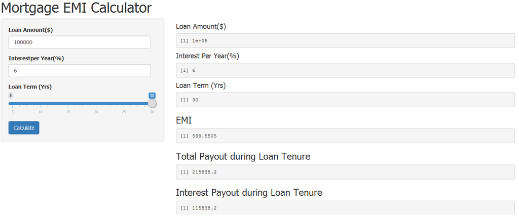

## How to input data

1. Loan Amount in $ - Fill amount of loan in Dollars as a number, for example,for a home loan of $200,000 , input value needs to be 200000.
2. Annual Rate if Interest in Percentage - Fill Annual Rate of Interest, for example, if the loan is taken at an annual rate of interest as 7%, then input value needs to be 7.
3. Loan Term in Years - Fill Loan term in years, for example if loan has to be repaid in 30 years, input value needs to be 30.

After filling required value, click on “Calculate” Button and it will show you the Monthly Installments to be paid, Total Payment in Repayment term and amount of interest that one will pay in loan term.

## Formulae and References

The monthly payment EMI depends upon:

1. r - the monthly interest rate, expressed as a decimal, not a percentage. The monthly percentage rate is simply the yearly percentage rate divided by 12; dividing the monthly percentage rate by 100 gives r.
2. N - the number of monthly payments, called the loan’s term, and
3. P - the amount borrowed, known as the loan’s principal.

In the standardized calculations used in the United States, EMI is given by the formula: $\frac{Pr(1+r)^N}{(1+r)^N-1}$ ## Reference: http://en.wikipedia.org/wiki/Mortgage_calculator